# Practical machine learning course project

Luigi Bernardi

The goal of this project is to predict if Unilateral Dumbbell Biceps Curl is performed correctly using data form accelerometers on the belt, forearm, arm, and dumbell of 6 participants to the experiment. Participants were asked to perform barbell lifts correctly and incorrectly in 5 different ways:

- exactly according to the specification (Class A),
- throwing the elbows to the front (Class B),
- lifting the dumbbell only halfway (Class C),
- lowering the dumbbell only halfway (Class D)
- throwing the hips to the front (Class E).

Class A corresponds to the specified execution of the exercise, while the other 4 classes correspond to common mistakes.

More information is available from the website here:  
http://web.archive.org/web/20161224072740/http:/groupware.les.inf.puc-rio.br/har

The training data for this project are available here:  
https://d396qusza40orc.cloudfront.net/predmachlearn/pml-training.csv

The test data are available here:  
https://d396qusza40orc.cloudfront.net/predmachlearn/pml-testing.csv

The **classe** variable in training set will be the outcome and a selection from the other variables will be used for prediction.

In this report I’ll briefly explain:

- how I built predictive model,
- how I used cross validation,
- expectation regarding out of sample error (accuracy).

Finally I’ll show results of my prection on the 20 cases in testing set.

## Loading libraries and data

Raw data were loaded into **pml_training_raw** and **pml_testing_raw** data frames. Then I selected all variables measuring movements (identified by **x**, **y** and **z** suffix) and used them as predictors. Final sets are:

- **pml_training** used for model building and estimating out of sample error (accuracy),
- **pml_testing** used for prediction on 20 cases in the set.

```r
library(tidyverse)
library(caret)
library(randomForest)
library(parallel)
library(doParallel)

pml_training_raw <- read.csv("https://d396qusza40orc.cloudfront.net/predmachlearn/pml-training.csv")
pml_testing_raw <- read.csv("https://d396qusza40orc.cloudfront.net/predmachlearn/pml-testing.csv")

pml_training <- pml_training_raw %>%
      select(classe, ends_with("_X"), ends_with("_y"), ends_with("_z"))

pml_testing <- pml_testing_raw %>%
      select(ends_with("_X"), ends_with("_y"), ends_with("_z"))
```

## Building predictive model with cross validation

For predicting proper execution of exercise I fitted a **random forest** model using **rf** method and **3 repeats of 5-fold cross validation** in **train()** function of caret package. Model was trained and evaluated splitting **pml_training** into a proper train set with 60% of cases (named **training**) and a test set with remaining 40% (named **testing**). Test set was used for bulding confusion matrix and estimating out of sample error (accuracy). Parallel computing was allowed.

```r
RNGversion("3.0.0")
set.seed(691979)

inTrain <- createDataPartition(y = pml_training$classe, p = 0.60, list=FALSE)

training <- pml_training[inTrain, ]
testing <- pml_training[-inTrain, ]

cluster <- makeCluster(detectCores() - 1) # uso parallel commputing
registerDoParallel(cluster)

pml_modfit_rf <- train(classe ~ .,
                       data = training,
                       method = "rf",
                       importance = T,
                       trControl = trainControl(method = "repeatedcv",
                                                number = 5,
                                                repeats = 3,
                                                allowParallel = T))
stopCluster(cluster)

pml_modfit_rf
```

```
## Random Forest
##
## 11776 samples
##    36 predictor
##     5 classes: 'A', 'B', 'C', 'D', 'E'
##
## No pre-processing
## Resampling: Cross-Validated (5 fold, repeated 3 times)
## Summary of sample sizes: 9421, 9421, 9421, 9420, 9421, 9420, ...
## Resampling results across tuning parameters:
##
##   mtry  Accuracy   Kappa
##    2    0.9796480  0.9742465
##   19    0.9757699  0.9693381
##   36    0.9698822  0.9618844
##
## Accuracy was used to select the optimal model using the largest value.
## The final value used for the model was mtry = 2.
```

```r
pml_modfit_rf$finalModel
```

```
##
## Call:
##  randomForest(x = x, y = y, mtry = param$mtry, importance = ..1)
##                Type of random forest: classification
##                      Number of trees: 500
## No. of variables tried at each split: 2
##
##         OOB estimate of  error rate: 1.66%
## Confusion matrix:
##      A    B    C    D    E class.error
## A 3334    2    4    7    1 0.004181601
## B   40 2210   28    1    0 0.030276437
## C    0   26 2028    0    0 0.012658228
## D    5    1   64 1857    3 0.037823834
## E    1    3    3    6 2152 0.006004619
```

Final model (**pml_modfit_rf**) has an **mtry** (the number of variables randomly sampled as candidates at each split) equal to **2**. Out Of Bag (**OOB**) estimate of error rate is **1.66%**. Following graph show that most important predictors are variables with measures from magnets and accelerometers placed on dumbells.

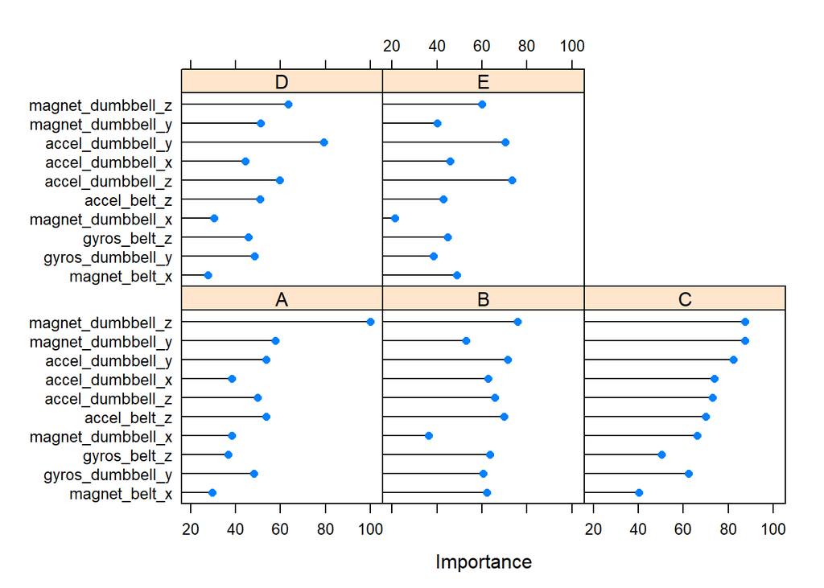

```r
plot(varImp(pml_modfit_rf), top = 10)
```

## Out of sample error (accuracy) and predictions for test cases

For an unbiased measure of the out of sample error (accuracy), predictions on test set were used to build a confusion matrix. **Out of sample error (accuracy) estimate is 0.9832**. 95% IC for the estimate is (0.9801, 0.9859).

```r
pml_modfit_rf_predict <- predict(pml_modfit_rf, testing)
confusionMatrix(pml_modfit_rf_predict, testing$classe)
```

```
## Confusion Matrix and Statistics
##
##           Reference
## Prediction    A    B    C    D    E
##          A 2227   33    1    2    0
##          B    2 1469   14    0    0
##          C    0   15 1352   46    5
##          D    3    1    1 1233    4
##          E    0    0    0    5 1433
##
## Overall Statistics
##
##                Accuracy : 0.9832
##                  95% CI : (0.9801, 0.9859)
##     No Information Rate : 0.2845
##     P-Value [Acc > NIR] : < 2.2e-16
##
##                   Kappa : 0.9787
##
##  Mcnemar's Test P-Value : NA
##
## Statistics by Class:
##
##                      Class: A Class: B Class: C Class: D Class: E
## Sensitivity            0.9978   0.9677   0.9883   0.9588   0.9938
## Specificity            0.9936   0.9975   0.9898   0.9986   0.9992
## Pos Pred Value         0.9841   0.9892   0.9535   0.9928   0.9965
## Neg Pred Value         0.9991   0.9923   0.9975   0.9920   0.9986
## Prevalence             0.2845   0.1935   0.1744   0.1639   0.1838
## Detection Rate         0.2838   0.1872   0.1723   0.1572   0.1826
## Detection Prevalence   0.2884   0.1893   0.1807   0.1583   0.1833
## Balanced Accuracy      0.9957   0.9826   0.9891   0.9787   0.9965
```

Finally I used model to predict values for the 20 cases in **pml_testing**.

```r
data.frame(case = 1:20,
           predicted_class = predict(pml_modfit_rf, pml_testing))
```

```
##    case predicted_class
## 1     1               B
## 2     2               A
## 3     3               B
## 4     4               A
## 5     5               A
## 6     6               E
## 7     7               D
## 8     8               B
## 9     9               A
## 10   10               A
## 11   11               B
## 12   12               C
## 13   13               B
## 14   14               A
## 15   15               E
## 16   16               E
## 17   17               A
## 18   18               B
## 19   19               B
## 20   20               B
```